# DS 202 - Homework #5

Gavin Herum

11-07-2023

## Flying etiquette

FiveThirtyEight is a website founded by Statistician and writer Nate Silver to publish results from opinion poll analysis, politics, economics, and sports blogging. One of the featured articles considers [flying etiquette](https://fivethirtyeight.com/features/airplane-etiquette-recline-seat/). This article is based on data collected by FiveThirtyEight and publicly available on github. Use the code below to read in the data from the survey:

```r
fly <- read.csv("https://raw.githubusercontent.com/fivethirtyeight/data/master/flying-etiquette-survey/flying-etiquette.csv")
```

The following couple of lines of code provide a bit of cleanup of the demographic information by reaordering the levels of the corresponding factor variables. Run this code in your session.

```r
fly$Age <- factor(fly$Age, levels=c("18-29", "30-44", "45-60", "> 60", ""))
fly$Household.Income <- factor(fly$Household.Income, levels = c("$0 - $24,999","$25,000 - $49,999", "$50,000 - $99,999", "$100,000 - $149,999", "150000", ""))
fly$Education <- factor(fly$Education, levels = c("Less than high school degree", "High school degree", "Some college or Associate degree", "Bachelor degree",  "Graduate degree", ""))
```

1. Download the RMarkdown file with these homework instructions to use as a template for your work. Make sure to replace “Your Name” in the YAML with your name.
2. Some people do not travel often by plane. Provide a (visual) breakdown of travel frequency (use variable `How.often.do.you.travel.by.plane.`). Reorder the levels in the variable by travel frequency from least frequent travel to most frequent. Draw a barchart of travel frequency and comment on it. Exclude all respondents who never fly from the remainder of the analysis. How many records does the data set have now?

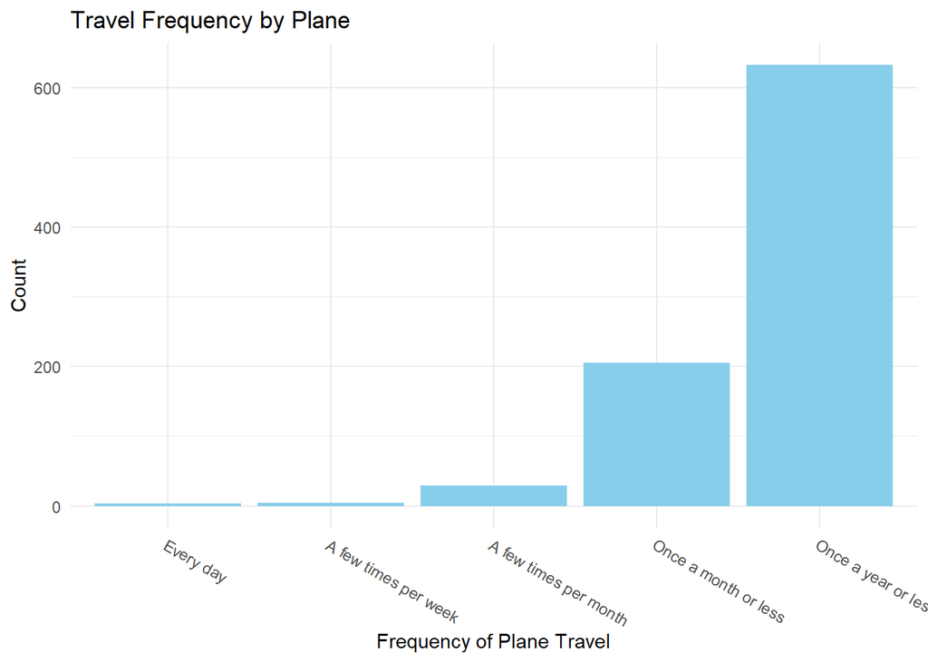

   ```r
   library(ggplot2)
   library(base)
   library(stats)
   library(dplyr)
   # Exclude respondents who never fly
   survey_data <- fly %>%
     filter(How.often.do.you.travel.by.plane. != "Never")

   # Reorder levels in the variable by travel frequency
   survey_data$How.often.do.you.travel.by.plane. <- factor(survey_data$How.often.do.you.travel.by.plane.,
                                                           levels = names(sort(table(survey_data$How.often.do.you.travel.by.plane.))))

   # Draw a barchart of travel frequency
   ggplot(survey_data, aes(x = How.often.do.you.travel.by.plane.)) +
     geom_bar(fill = "skyblue") +
     labs(title = "Travel Frequency by Plane",
          x = "Frequency of Plane Travel",
          y = "Count") +
     theme_minimal() +
     theme(axis.text.x=element_text(angle = -30, hjust = 0))
   ```

   ```r
   # Number of records in the dataset
   n_records <- nrow(survey_data)
   n_records
   ```

   ```
   ## [1] 874
   ```

   There are 874 records in the survey data now.
3. In the demographic variables (`Education`, `Age`, and `Houshold.Income`), replace all occurrences of the empty string “” by a missing value `NA`. How many responses in each variable do not have any missing values? How many responses have no missing values in any of the three variables? (Hint: think of the function `is.na`)

   ```r
   # Replace empty strings with NA
   survey_data$Education <- ifelse(survey_data$Education == "", NA, survey_data$Education)
   survey_data$Age <- ifelse(survey_data$Age == "", NA, survey_data$Age)
   survey_data$Household.Income <- ifelse(survey_data$Household.Income == "", NA, survey_data$Household.Income)

   # Count responses without missing values in each variable
   education_no_missing <- sum(!is.na(survey_data$Education))
   age_no_missing <- sum(!is.na(survey_data$Age))
   income_no_missing <- sum(!is.na(survey_data$Household.Income))

   # Count responses with no missing values in any of the three variables
   no_missing_all <- sum(complete.cases(survey_data[c("Education", "Age", "Household.Income")]))

   # Display the counts
   print(paste("Number of responses without missing values in Education:", education_no_missing))
   ```

   ```
   ## [1] "Number of responses without missing values in Education: 837"
   ```

   ```r
   print(paste("Number of responses without missing values in Age:", age_no_missing))
   ```

   ```
   ## [1] "Number of responses without missing values in Age: 843"
   ```

   ```r
   print(paste("Number of responses without missing values in Household Income:", income_no_missing))
   ```

   ```
   ## [1] "Number of responses without missing values in Household Income: 698"
   ```

   ```r
   print(paste("Number of responses with no missing values in any of the three variables:", no_missing_all))
   ```

   ```
   ## [1] "Number of responses with no missing values in any of the three variables: 696"
   ```

4. Run the command below and interpret the output. What potential purpose can you see for the chart? What might be a problem with the chart? Find at least one purpose and one problem.

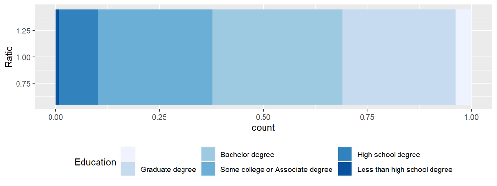

```r
library(ggplot2)
fly$Education = with(fly, factor(Education, levels = rev(levels(Education))))

ggplot(data = fly, aes(x = 1)) +
  geom_bar(aes(fill=Education), position="fill") +
  coord_flip() +
  theme(legend.position="bottom") +
  scale_fill_brewer() +
  xlab("Ratio")
```

At a surface level, this is a bar chart separating out the level of education and showing proportionally the education level of the people surveyed. One problem, is that a bar chart is not the best way to show the proportions of a data set. Bar charts make it hard to compare between them with good reference especially because there isn’t a great reference point on the X axis only showing every 25% mark.

5. Rename the variable `In.general..is.itrude.to.bring.a.baby.on.a.plane.` to `baby.on.plane.`. How many levels does the variable `baby.on.plane` have, and what are these levels? Rename the level labeled “” to “Not answered”. Bring the levels of `baby.on.plane` in an order from least rude to most rude. Put the level “Not answered” last. Draw a barchart of variable `baby.on.plane`. Interpret the result. (This question is very similar to question 2, but preps the data for the next question)

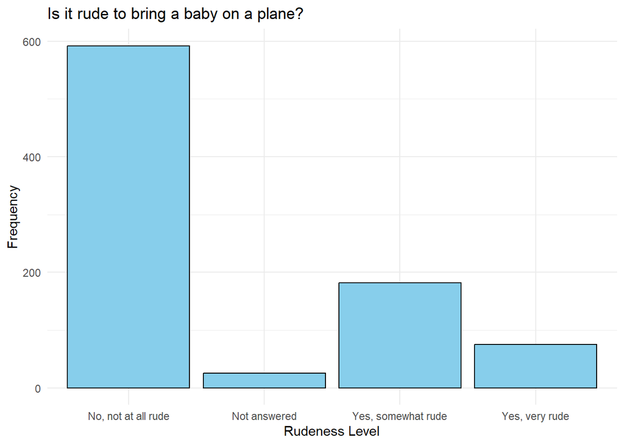

   ```r
   # Rename the variable
   data <- survey_data %>% rename(baby.on.plane = In.general..is.itrude.to.bring.a.baby.on.a.plane.)

   # Replace "" level to "Not answered"
   data$baby.on.plane <- sub("^$", "Not answered", data$baby.on.plane)


   # Draw a bar chart
   ggplot(data, aes(x = baby.on.plane)) +
     geom_bar(fill = "skyblue", color = "black") +
     labs(title = "Is it rude to bring a baby on a plane?",
          x = "Rudeness Level",
          y = "Frequency") +
     theme_minimal()
   ```

6. Investigate the relationship between gender and the variables `Do.you.have.any.children.under.18.` and `baby.on.plane`. How is the attitude towards babies on planes shaped by gender and own children under 18? Find a plot that summarises your findings (use `ggplot2`).

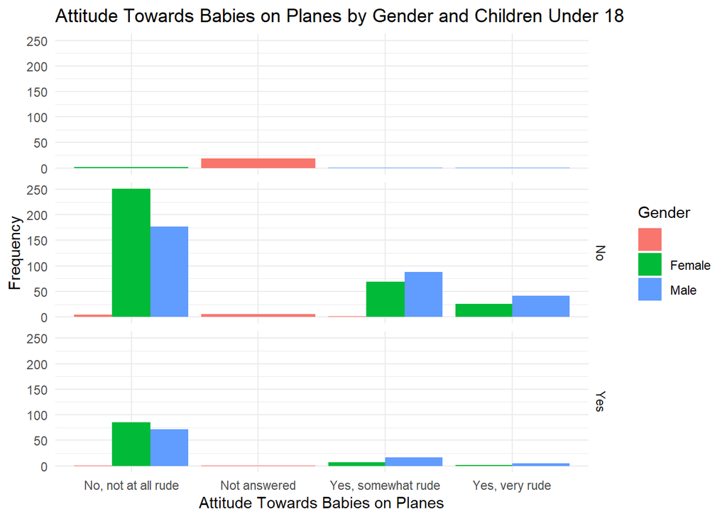

   ```r
   # Filter out rows with missing values in the relevant columns
   data_filtered <- data %>%
     filter(!is.na(Gender) & !is.na(Do.you.have.any.children.under.18.) & !is.na(baby.on.plane))

   # Create a plot
   ggplot(data_filtered, aes(x = baby.on.plane , fill = Gender)) +
     geom_bar(position = "dodge") +
     facet_grid(Do.you.have.any.children.under.18. ~ .) +
     labs(title = "Attitude Towards Babies on Planes by Gender and Children Under 18",
          x = "Attitude Towards Babies on Planes",
          y = "Frequency",
          fill = "Gender") +
     theme_minimal()
   ```

We can see that generally people without children are more likely to see children as rude. However, there is less entries from people with children so, the correlations should not be looked into too deeply. I do think however that this trend makes sense.

For the submission: submit your solution in an R Markdown file and (just for insurance) submit the corresponding html/word file with it.